[figure not shown]

Maestría · Visión Artificial · Sesión 6

# Redes neuronales: de la neurona a la convolución

**Dr. Víctor Alejandro González Huitrón**  
Instituto Tecnológico de Querétaro · TecNM  
Departamento de Sistemas y Computación

01

Del rasgo diseñado al rasgo aprendido

# ¿Quién decide qué mirar?

En Viola-Jones una persona **diseñó** los rasgos (Haar) y AdaBoost solo **eligió** entre ellos. Hoy la red **aprende** los rasgos a partir de los datos.

## De los rasgos Haar a los filtros aprendidos

[figure not shown]

- **Haar:** patrón fijo de rectángulos; AdaBoost escoge entre >160 000 candidatos que alguien definió.
- **Filtro convolucional:** una matriz de pesos que se **ajusta** con los datos.
- Las primeras capas terminan aprendiendo **detectores de borde y de contraste**, parecidos a Haar, HOG o Gabor, sin que nadie los diseñe.

Coloresámbar = peso positivo · azul = peso negativo. Mismo código en toda la sesión.

## ¿Qué problemas resuelve la visión con redes profundas?

[figure not shown]

La salida cambia de **una etiqueta** a **cajas**, a **un valor por píxel**, a **una imagen completa**. Todas comparten el mismo bloque base: capas convolucionales que extraen rasgos.

P1 · clasificación en el bordeP2 · lesiones: clasificación/detección P3 · ADAS: detección + segmentaciónP4 · YOLO = detección

02

Intuición

# ¿Qué hace por dentro una red neuronal?

Seguimos el ejemplo de **3Blue1Brown**: reconocer dígitos manuscritos. La meta es entender el mecanismo, para después ver sus **ventajas y límites**.

## El problema: MNIST

- **70 000** dígitos manuscritos: 60 000 de entrenamiento y 10 000 de prueba.
- Imágenes de **28 × 28** en escala de grises (0–255), centradas y normalizadas a una caja de 20 × 20.
- 10 clases (0–9). El “hola mundo” del aprendizaje profundo (LeCun et al., 1998).

MNIST está prácticamente resuelto (>99.7 %). Sirve para **entender** mecanismos, no para comparar modelos actuales.

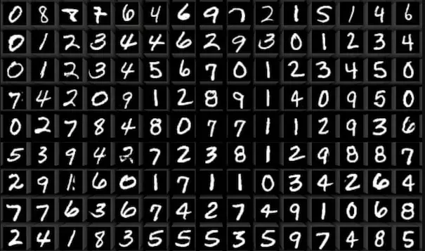

Muestras de MNIST

## Reconocer un patrón

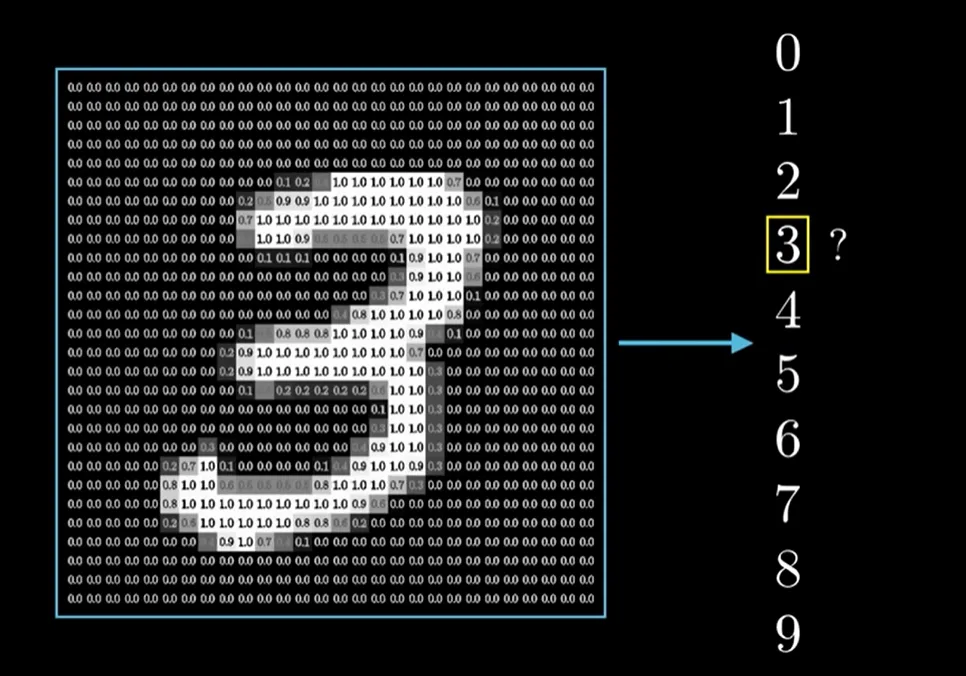

Imagen: 3Blue1Brown, “But what is a neural network?” (2017)

¿Cómo pasar de **784 números** a “esto es un 3”?

- Para nosotros es trivial; escribir las **reglas a mano** es casi imposible.
- El mismo dígito cambia en grosor, inclinación, posición y estilo: los píxeles encendidos son **distintos** cada vez.
- Necesitamos una función con muchos parámetros que **aprenda** esa correspondencia a partir de ejemplos.

## La red completa: 784 → 16 → 16 → 10

[video not shown]

Animación: 3Blue1Brown (2017)

- **Entrada:** 784 neuronas, una por píxel.
- **Dos capas ocultas** de 16 neuronas.
- **Salida:** 10 neuronas, una por dígito; la más activa es la predicción.

¿Por qué 2 capas de 16? Es una **decisión de diseño** (hiperparámetro), no una ley. Es la red que entrenamos para las demos de hoy.

## Una neurona guarda un número

- Cada neurona contiene un valor: su **activación**.
- En la capa de entrada, la activación es la **intensidad del píxel** escalada a 0–1 (0 = negro, 1 = blanco).
- 28 × 28 = **784** activaciones describen la imagen completa.

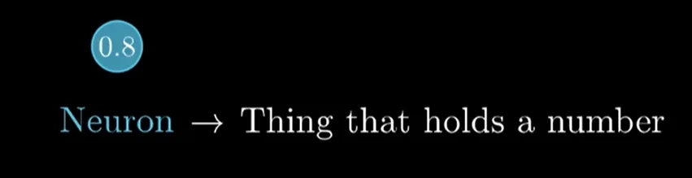

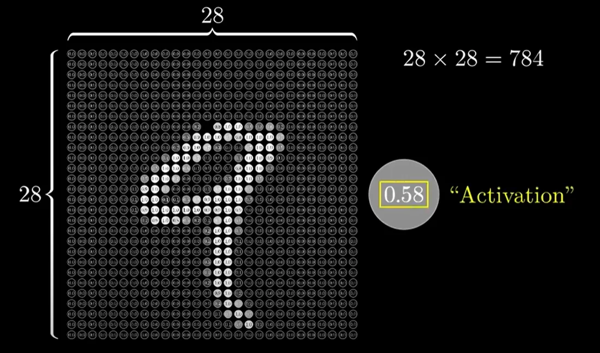

Imágenes: 3Blue1Brown (2017)

## Las activaciones se propagan

[video not shown]

Animación: 3Blue1Brown (2017)

El patrón de activaciones de una capa **determina** el de la siguiente.

No hay reglas del tipo “si hay un lazo arriba…”: hay una **cascada de números** calculada con pesos.

RecuerdaEn la cascada de Viola-Jones cada etapa podía **detener** el proceso. Aquí siempre se evalúan **todas** las capas.

## La esperanza: capas ocultas que detectan partes

[video not shown]

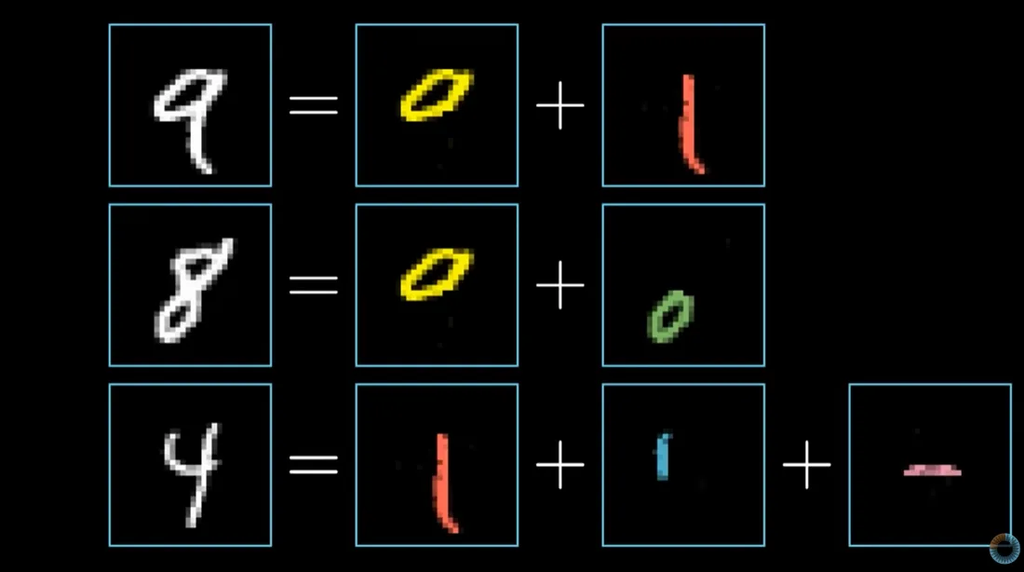

[figure not shown]

Hipótesis: capa 2 → **bordes**; capa 3 → **partes** (lazos, trazos); salida → **combinación** de partes. 9 = lazo arriba + línea a la derecha.

Imágenes y animación: 3Blue1Brown (2017)

## Lo que la red realmente aprende

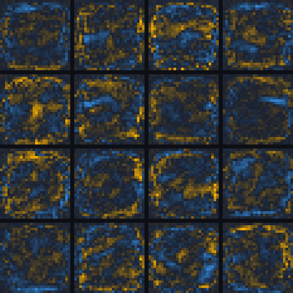

Pesos de las 16 neuronas de la capa oculta 1 de **nuestro** MLP entrenado (95.4 % en prueba). Ámbar = positivo, azul = negativo.

- Si la hipótesis fuera cierta veríamos **bordes y trazos limpios**.
- Lo que aparece son **patrones difusos**, parecidos a ruido estructurado.
- La red resuelve el problema, pero **no necesariamente como lo imaginamos**: encuentra cualquier combinación de pesos que baje el error.

Primera limitante: es **difícil de interpretar**. Funciona sin “entender” en términos humanos.

## Pesos: qué mira cada neurona

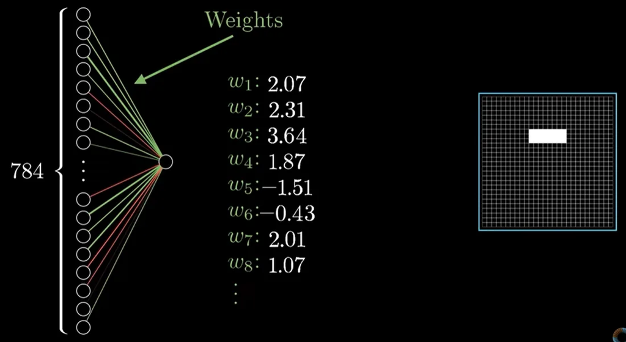

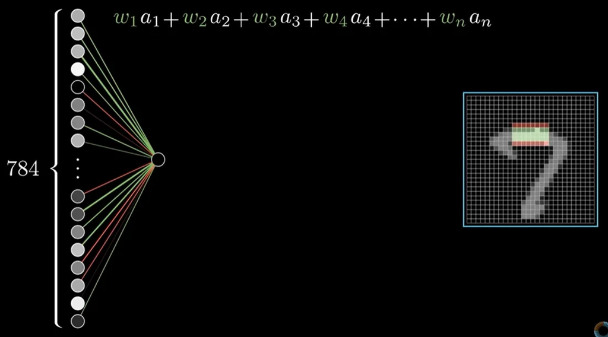

Imágenes: 3Blue1Brown (2017)

z = w<sub>1</sub>a<sub>1</sub> + w<sub>2</sub>a<sub>2</sub> + … + w<sub>784</sub>a<sub>784</sub>

- Cada conexión tiene un **peso** w. La neurona calcula una **suma ponderada**.
- Pesos dibujados sobre la cuadrícula: verde/positivo donde “quiere” luz, rojo/negativo donde “quiere” oscuridad.
- Rodear una franja positiva con pesos negativos la vuelve un **detector de borde**: la misma idea que un rasgo Haar.

## Activación y sesgo

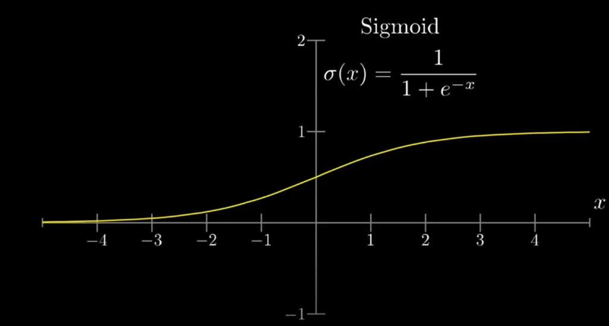

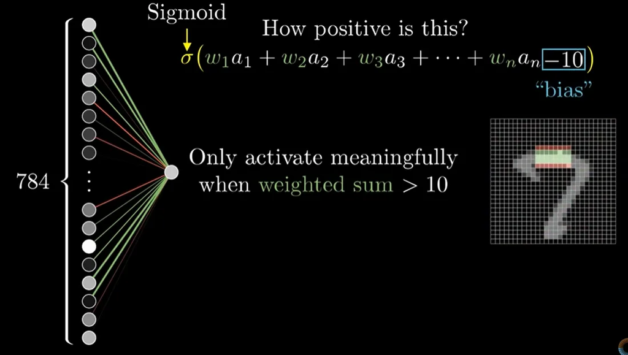

Imágenes: 3Blue1Brown (2017)

a = σ( w·a<sub>prev</sub> + b )

- La suma puede valer cualquier número: una **función de activación** la “aplasta” o recorta.
- El **sesgo b** decide a partir de qué valor la neurona se enciende (“solo actívate si la suma > 10” → b = −10).
- Sin la no linealidad, apilar capas equivale a **una sola** transformación lineal.

## Funciones de activación: de la sigmoide a ReLU

z = **0**

f(z)derivada f′(z)

- **Sigmoide / tanh:** históricas. Se **saturan**: para |z| grande la derivada ≈ 0. La de la sigmoide nunca pasa de **0.25**.
- **ReLU** = max(0, z): estándar en capas ocultas desde AlexNet (2012). Barata y con derivada 1 para z > 0.
- **Leaky ReLU, GELU, SiLU:** variantes que evitan neuronas “muertas”; GELU/SiLU en arquitecturas modernas.

Ocultas → **ReLU** (o variante). Salida → **softmax** (multiclase) o **sigmoide** (binaria).

## Contar parámetros: 13 002 perillas

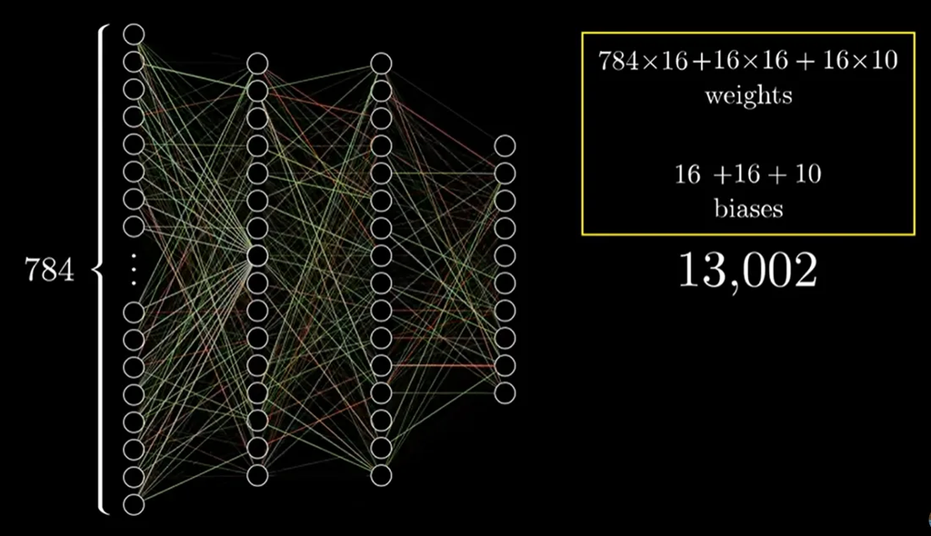

Imagen: 3Blue1Brown (2017)

**Pesos** · 784·16 + 16·16 + 16·10 = **12 960**

**Sesgos** · 16 + 16 + 10 = **42**

**Total** · **13 002** parámetros

Entrenar es encontrar los 13 002 valores que hacen que la red clasifique bien. Keras lo confirma en model.summary().

El 97 % de los pesos está en la primera capa: **784 × 16**. Guarden este dato; será el problema central con imágenes grandes.

## Una capa es una multiplicación de matrices

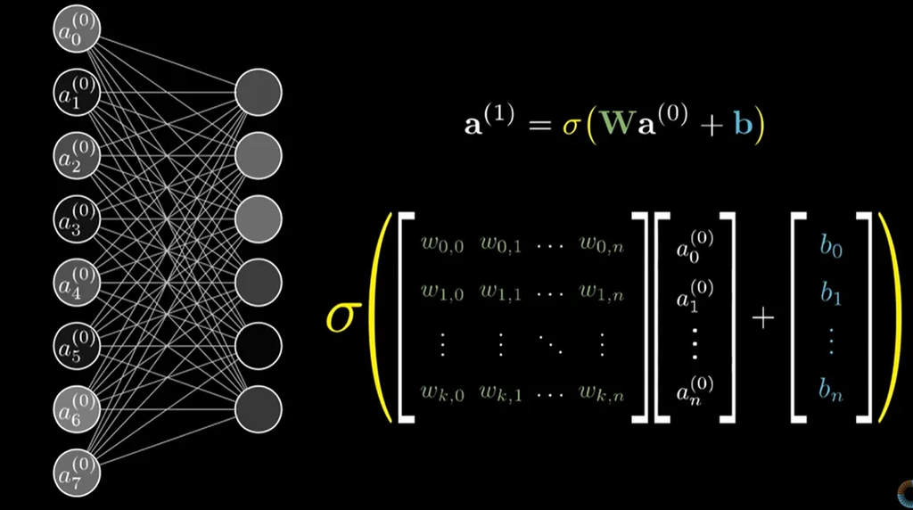

Imagen: 3Blue1Brown (2017)

a<sup>(1)</sup> = σ( W a<sup>(0)</sup> + b )

- Cada fila de **W** son los pesos de una neurona; el producto calcula todas las sumas a la vez.
- Con un lote de imágenes es una **matriz por matriz**: justo lo que las GPU aceleran.
- En Keras, Dense guarda W con forma (entradas, salidas) y calcula x·W + b.

03

Aprendizaje

# ¿Cómo aprende?

Costo, descenso de gradiente y retropropagación, con un ejemplo numérico que se puede hacer a mano.

## Una red sin entrenar es basura

[video not shown]

Animación: 3Blue1Brown (2017)

Con pesos y sesgos **aleatorios**, la salida no tiene relación con el dígito de entrada.

Necesitamos una forma de **medir** qué tan mal está y una forma de **corregir** los 13 002 parámetros en la dirección correcta.

InicializaciónHoy se usan esquemas como **He/Kaiming** o **Glorot**, que escalan los pesos aleatorios según el tamaño de la capa.

## Función de costo: de MSE a entropía cruzada

[video not shown]

El video usa error cuadrático (MSE) · 3Blue1Brown (2017)

p<sub>k</sub> = e<sup>z<sub>k</sub></sup> / Σ<sub>j</sub> e<sup>z<sub>j</sub></sup> L = −log p<sub>correcta</sub>softmax convierte 10 números en probabilidades · entropía cruzada castiga la probabilidad baja de la clase correcta

En clasificación se usa **softmax + entropía cruzada**: castiga fuerte una predicción segura y equivocada y da gradientes útiles; MSE + sigmoide aprende lento cuando la salida se satura.

## Descenso de gradiente

[video not shown]

Animación: 3Blue1Brown (2017)

w ← w − η · ∂L/∂w

- El costo es una superficie sobre los 13 002 parámetros; el **gradiente** apunta hacia donde sube.
- Damos un paso en sentido contrario. **η** (tasa de aprendizaje) controla el tamaño del paso.
- Se estima con **minilotes** (SGD): 64 imágenes por paso en nuestro entrenamiento.

Optimizadores actuales: **Adam / AdamW**, que adaptan el paso de cada parámetro. Los mínimos locales preocupan menos de lo que sugiere el dibujo 1D.

## Entrenamiento en progreso

[video not shown]

Animación: 3Blue1Brown (2017)

Nuestro MLP 784-16-16-10 · Keras 3 (backend PyTorch) · Adam, lote 64, 15 épocas. Exactitud final en prueba: **95.4 %**.

## Ejemplo numérico 1: el paso hacia adelante

[figure not shown]

1. **Suma ponderada:**  
   z = 0.4·0.5 + 0.3·(−1) + (−0.2)·2 + 0.1  
   = 0.2 − 0.3 − 0.4 + 0.1 = **−0.4**
2. **Activación:** a = σ(−0.4) = 1/(1+e<sup>0.4</sup>) = **0.401**
3. **Pérdida** (entropía cruzada binaria, y = 1):  
   L = −log(0.401) = **0.913**

LecturaLa neurona da 40 % a la clase correcta: se equivoca. ¿Cuánto culpa tiene cada peso?

## Ejemplo numérico 2: regla de la cadena y actualización

∂L/∂w₁ = ∂L/∂a · ∂a/∂z · ∂z/∂w₁= (−1/a) · a(1−a) · x₁ = (−2.492)(0.240)(0.5) = −0.299 → se simplifica a (a − y)·x₁

| Parámetro | Valor | Gradiente (a−y)·x | Nuevo (η = 0.5) |
| --- | --- | --- | --- |
| w₁ | 0.400 | −0.599 · 0.5 = −0.299 | **0.550** |
| w₂ | 0.300 | −0.599 · (−1) = 0.599 | **0.001** |
| w₃ | −0.200 | −0.599 · 2 = −1.197 | **0.399** |
| b | 0.100 | −0.599 | **0.399** |

Los pesos con entrada grande (x₃ = 2) reciben más culpa. Con miles de ejemplos y millones de pasos, esto es todo el aprendizaje.

## Retropropagación en una red completa

[figure not shown]

- El error de la salida se **reparte hacia atrás** capa por capa: cada peso recibe su “culpa”.
- Es la **regla de la cadena** organizada para no repetir cálculos: un pase adelante + uno atrás ≈ 2–3× el costo de predecir.
- Si cada capa multiplica el gradiente por algo pequeño (derivada de la sigmoide ≤ 0.25), en capas profundas **se desvanece**.

Keras/PyTorch la calculan solos (**autodiff**). Entenderla explica por qué ReLU, la buena inicialización y las conexiones residuales (sesión 7) permiten redes profundas.

## Demo: dibuja un dígito

Red real: el MLP de 13 002 parámetros que entrenamos, ejecutándose en el navegador. Pruebe: dibujar, **apagar el centrado** y dibujar en una esquina, desplazar 3 px, reducir. Clic en una neurona de la capa oculta 1 para ver sus pesos.

04

Ventajas y límites

# ¿Por qué no basta una red densa para imágenes?

Lo que la red totalmente conectada (MLP) hace bien, y tres límites medidos con **nuestro** modelo.

## Lo que una red densa hace bien

[figure not shown]

- **Aproximador universal:** con suficientes neuronas aproxima cualquier función continua (Cybenko 1989; Hornik 1991).
- **Aprende de los datos**, sin reglas escritas a mano.
- Se entrena **de punta a punta** con un solo procedimiento: costo + gradiente.
- Excelente en datos **tabulares** o vectores de rasgos ya extraídos (P5).

Pero“Puede aproximar” no dice **cuántos parámetros** ni **cuántos datos** necesita. Ahí aparecen los límites.

## Límite 1: explosión de parámetros

- Cada neurona se conecta con **todos** los píxeles: pesos = píxeles × neuronas.
- Imagen de 1000 × 1000 × 3 = 3 M de entradas → **3 000 M** de pesos en la primera capa (12 GB en float32).
- Más parámetros exigen más datos; con pocos datos, **sobreajuste**.

El problema no es la profundidad: es conectar **cada píxel con cada neurona**.

## Límite 2: no hay invariancia a la traslación

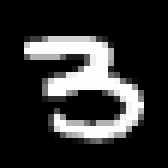

0 px  
predice **3** (100 %)

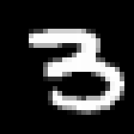

2 px  
predice **3** (92 %)

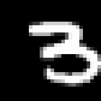

4 px  
predice **2** (100 %)

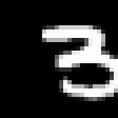

6 px  
predice **2** (100 %)

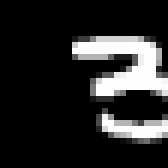

8 px  
predice **2** (71 %)

El mismo “3” de prueba, desplazado a la derecha. Predicción del MLP debajo.

- Desplazado, es **otro vector** de 784 números: los píxeles encendidos caen en entradas con otros pesos.
- La red densa tendría que aprender **cada posición por separado**.

Exactitud del MLP en las 10 000 imágenes de prueba desplazadas k píxeles: de 95.4 % a 34.2 % con solo 4 píxeles.

## Límite 3: ignora la estructura espacial

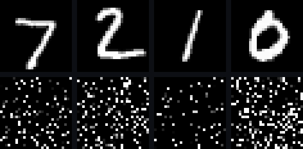

Arriba: dígitos originales. Abajo: los mismos píxeles con un **orden fijo aleatorio**.

Experimento: reordenamos los 784 píxeles **siempre con la misma permutación** y entrenamos otro MLP idéntico.

Funciona **igual de bien**: el MLP no sabe qué píxel es vecino de cuál. Toda la geometría de la imagen se pierde al aplanarla.

Para una imagen, la **vecindad** lo es todo: bordes, texturas y formas son relaciones entre píxeles cercanos.

## Lo que necesitamos de una red para imágenes

[figure not shown]

05

La operación base

# La convolución

Un filtro pequeño que recorre la imagen. Ya lo usaron en preprocesamiento; ahora sus valores se **aprenden**.

## Detectar bordes con un filtro 3×3

[interactive chart not shown]

entrada (escala de grises)

[interactive chart not shown]

salida del filtro

Filtro (editable):

- Cada píxel de salida = suma de los 9 vecinos **multiplicados** por el filtro.
- **Borde vertical** resalta cambios izquierda–derecha; **horizontal**, arriba–abajo.
- Pruebe escribir su propio filtro: ¿qué hace [0 0 0; 0 2 0; 0 0 0]?

Imagen “cameraman”, scikit-image (dominio público)

## Convolución paso a paso

entrada 6×6

∗

filtro 3×3

=

salida 4×4

Sin relleno y con paso 1: 6 − 3 + 1 = 4. En código: keras.layers.Conv2D, torch.nn.Conv2d, cv2.filter2D.

## ¿Por qué funciona como detector de borde?

| 10 | 10 | 10 | 0 | 0 | 0 |
| --- | --- | --- | --- | --- | --- |
| 10 | 10 | 10 | 0 | 0 | 0 |
| 10 | 10 | 10 | 0 | 0 | 0 |
| 10 | 10 | 10 | 0 | 0 | 0 |
| 10 | 10 | 10 | 0 | 0 | 0 |
| 10 | 10 | 10 | 0 | 0 | 0 |

∗

| 1 | 0 | −1 |
| --- | --- | --- |
| 1 | 0 | −1 |
| 1 | 0 | −1 |

=

| 0 | 30 | 30 | 0 |
| --- | --- | --- | --- |
| 0 | 30 | 30 | 0 |
| 0 | 30 | 30 | 0 |
| 0 | 30 | 30 | 0 |

claro → oscuro: franja **+30** justo en la frontera

| 0 | 0 | 0 | 10 | 10 | 10 |
| --- | --- | --- | --- | --- | --- |
| 0 | 0 | 0 | 10 | 10 | 10 |
| 0 | 0 | 0 | 10 | 10 | 10 |
| 0 | 0 | 0 | 10 | 10 | 10 |
| 0 | 0 | 0 | 10 | 10 | 10 |
| 0 | 0 | 0 | 10 | 10 | 10 |

∗

| 1 | 0 | −1 |
| --- | --- | --- |
| 1 | 0 | −1 |
| 1 | 0 | −1 |

=

| 0 | −30 | −30 | 0 |
| --- | --- | --- | --- |
| 0 | −30 | −30 | 0 |
| 0 | −30 | −30 | 0 |
| 0 | −30 | −30 | 0 |

oscuro → claro: franja **−30**; el signo codifica la **polaridad**

- En zonas uniformes la columna +1 y la −1 se cancelan → **0**. Solo responde donde hay **cambio**: es una derivada discreta.
- La franja se ve gruesa porque la imagen es de 6×6; en una imagen de 1000×1000 es una línea delgada. Igual que el rasgo Haar A de la sesión 5.

## Vertical, horizontal y otros filtros clásicos

| 10 | 10 | 10 | 0 | 0 | 0 |
| --- | --- | --- | --- | --- | --- |
| 10 | 10 | 10 | 0 | 0 | 0 |
| 10 | 10 | 10 | 0 | 0 | 0 |
| 0 | 0 | 0 | 10 | 10 | 10 |
| 0 | 0 | 0 | 10 | 10 | 10 |
| 0 | 0 | 0 | 10 | 10 | 10 |

∗

| 1 | 1 | 1 |
| --- | --- | --- |
| 0 | 0 | 0 |
| −1 | −1 | −1 |

=

| 0 | 0 | 0 | 0 |
| --- | --- | --- | --- |
| 30 | 10 | −10 | −30 |
| 30 | 10 | −10 | −30 |
| 0 | 0 | 0 | 0 |

Filtro horizontal sobre un tablero: ±30 en bordes completos; **±10** donde la ventana mezcla zonas

| Filtro | Valores | Idea |
| --- | --- | --- |
| **Vertical** (Prewitt x) | [1 0 −1] ×3 filas | derivada horizontal |
| **Horizontal** (Prewitt y) | transpuesto | derivada vertical |
| **Sobel** | [1 0 −1; 2 0 −2; 1 0 −1] | más peso al centro, menos ruido |
| **Scharr** | [3 0 −3; 10 0 −10; 3 0 −3] | mejor simetría rotacional |

¿Cuál es el mejor? Depende de los datos. En lugar de elegirlo… **que la red lo aprenda**.

## Aprender el filtro

| w₁ | w₂ | w₃ |
| --- | --- | --- |
| w₄ | w₅ | w₆ |
| w₇ | w₈ | w₉ |

←

retropropagación  
**∂L/∂wᵢ**

- Los 9 valores del filtro (+ un sesgo) son **parámetros**, igual que los pesos de la sección 03.
- El gradiente se calcula igual: regla de la cadena. Nada nuevo en el aprendizaje.
- Esta es la diferencia con Viola-Jones: el rasgo ya no se **elige**, se **optimiza**.

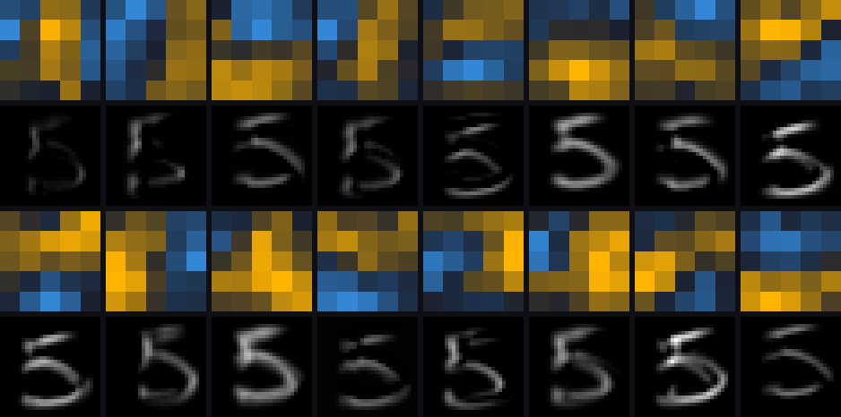

Nuestra CNN, capa conv1: cada filtro 5×5 aprendido (arriba) y su mapa de activación para un “5” (abajo). Varios son detectores de borde con orientación distinta.

## Nota técnica: correlación cruzada vs. convolución

[figure not shown]

(I ⋆ K)(i,j) = Σ I(i+m, j+n) K(m,n) vs (I ∗ K)(i,j) = Σ I(i−m, j−n) K(m,n)

- La convolución de los libros voltea el filtro; las CNN **no** lo hacen: técnicamente calculan **correlación cruzada**.
- Por convención se le llama convolución. Como el filtro se **aprende**, voltearlo es irrelevante: la red aprendería la versión volteada.
- Importa al comparar con scipy.signal.convolve2d o al portar filtros clásicos.

## Padding: valid y same

[figure not shown]

Sin relleno hay dos problemas:

- La imagen se **encoge** en cada capa (6 → 4 → 2 …).
- Las **orillas** participan menos: se pierde información en los bordes.

**valid**: sin relleno → n − f + 1

**same**: p = (f − 1)/2 → salida = entrada

Por eso los filtros suelen ser de tamaño **impar** (3, 5, 7): hay un píxel central y el relleno es simétrico.

## Stride (paso)

[figure not shown]

n<sub>out</sub> = ⌊ (n + 2p − f) / s ⌋ + 1⌊ ⌋ = piso: si la ventana no cabe completa, esa posición se descarta

- El filtro avanza **s píxeles** en cada paso (horizontal y vertical).
- Ejemplo: 7×7, filtro 3×3, s = 2 → ⌊(7 − 3)/2⌋ + 1 = **3×3**.
- Stride > 1 **reduce** la resolución y el costo, sin parámetros extra.

Fe de erratas: en las diapositivas originales de este ejemplo aparecen 83 y 127; los valores correctos son **88** y **117**.

## Calculadora de dimensiones

n canales n<sub>c</sub> f p s filtros

Ejemplos:

06

De 2D a volúmenes

# La capa convolucional

Imágenes a color, varios filtros a la vez, sesgo y ReLU: la misma neurona de la sección 02, con **pesos compartidos** y **conexión local**.

## Convolución sobre una imagen RGB

[figure not shown]

- Entrada 6×6×**3** → el filtro también tiene **3** canales: 3×3×3 = 27 pesos.
- En cada posición: 27 productos + sesgo → **un solo número**.
- El cubo se desliza solo en alto y ancho: salida **4×4×1**.

Regla: canales del filtro = canales de la entrada. Un filtro puede buscar, por ejemplo, bordes **solo en el canal rojo** (ceros en G y B).

## Varios filtros = una capa convolucional

[figure not shown]

z<sup>[l]</sup> = W<sup>[l]</sup> ∗ a<sup>[l−1]</sup> + b<sup>[l]</sup> a<sup>[l]</sup> = ReLU(z<sup>[l]</sup>)igual que la neurona densa: z = Wa + b, a = g(z), pero ∗ es convolución

Cada filtro produce un **mapa de activación**; se suma su sesgo, se aplica ReLU y los mapas se **apilan**: 2 filtros → volumen 4×4×**2**. Con 10 filtros, 4×4×10.

## ¿Cuántos parámetros tiene una capa?

10 filtros de 3×3×3: (27 + 1) × 10 = 280

- No depende del tamaño de la imagen: 280 parámetros para 64×64 o para 4000×3000.
- Pocos parámetros → menos datos necesarios y **menos sobreajuste**.

Corrección: eso **no** significa que la red acepte cualquier tamaño. La capa densa final exige un tamaño fijo, salvo que se use **global pooling** (sección 07).

| Símbolo (capa l) | Significado |
| --- | --- |
| f<sup>[l]</sup>, p<sup>[l]</sup>, s<sup>[l]</sup> | tamaño de filtro, relleno, paso |
| n<sub>c</sub><sup>[l]</sup> | número de filtros = canales de salida |
| entrada | n<sub>H</sub><sup>[l−1]</sup> × n<sub>W</sub><sup>[l−1]</sup> × n<sub>c</sub><sup>[l−1]</sup> |
| cada filtro | f × f × n<sub>c</sub><sup>[l−1]</sup> |
| pesos | f × f × n<sub>c</sub><sup>[l−1]</sup> × n<sub>c</sub><sup>[l]</sup> (+ n<sub>c</sub><sup>[l]</sup> sesgos) |
| salida | n<sub>H</sub><sup>[l]</sup> × n<sub>W</sub><sup>[l]</sup> × n<sub>c</sub><sup>[l]</sup> |

Orden de ejes: Keras usa **canales al final** (N, H, W, C); PyTorch usa **canales primero** (N, C, H, W). Keras con backend PyTorch mantiene canales al final por defecto.

07

Reducir y ensamblar

# Pooling y una CNN completa

Tres tipos de capa: **convolución**, **pooling** y **totalmente conectada**.

## Max pooling

→

f s

- Ventana f × f con paso s: se queda el **máximo**. Pase el cursor sobre la salida.
- Si el canal es un detector de borde, conserva la **respuesta más fuerte** sin importar su posición exacta dentro de la ventana.
- Se aplica **canal por canal**: 5×5×n<sub>c</sub> → 3×3×n<sub>c</sub>.
- **No tiene parámetros**. El gradiente sí pasa: solo hacia la posición del máximo.

## Average pooling y global average pooling

[figure not shown]

- **Average pooling**: el promedio de la ventana (ejemplo de la izquierda: 4×4 → [3.75 1.25; 4 2]).
- **Global average pooling (GAP)**: un promedio por canal sobre todo el mapa: 7×7×512 → **512**.

GAP reemplaza las capas densas grandes en redes modernas (NiN, GoogLeNet, ResNet): menos parámetros y acepta entradas de distinto tamaño. Nuestra CNN de la demo lo usa.

## Una ConvNet simple, capa por capa

[figure not shown]

Clasificador binario (¿gato? 0/1). Cada dimensión sale de ⌊(n + 2p − f)/s⌋ + 1: (37 − 5)/2 + 1 = 17, (17 − 5)/2 + 1 = 7. Al final, 7·7·40 = 1960 valores → **sigmoide** (binaria; en el material original decía softmax).

Tendencia: alto y ancho **bajan**, canales **suben**.

## Una CNN tipo LeNet-5: dimensiones y parámetros

[figure not shown]

| Capa | Forma | Activaciones | Parámetros |
| --- | --- | --- | --- |
| Entrada | 32×32×3 | 3 072 | 0 |
| CONV1 (f=5, s=1, 6) | 28×28×6 | 4 704 | (5·5·3+1)·6 = 456 |
| POOL1 (max, f=2, s=2) | 14×14×6 | 1 176 | 0 |
| CONV2 (f=5, s=1, 16) | 10×10×16 | 1 600 | (5·5·6+1)·16 = 2 416 |
| POOL2 (max, f=2, s=2) | 5×5×16 | 400 | 0 |
| FC3 | 120 | 120 | 400·120+120 = 48 120 |
| FC4 | 84 | 84 | 10 164 |
| Softmax | 10 | 10 | 850 |

Total ≈ **62 006**; el **95 %** está en las capas densas. Las activaciones se reducen de 3 072 a 10.

LeNet-5 (LeCun et al., 1998): entrada 32×32×**1**, tanh y submuestreo por promedio, ~60 mil parámetros. Tabla corregida a 6 filtros (el material original mezclaba 8 y 6).

08

El balance

# ¿Por qué convoluciones?

Volvemos a los tres límites del MLP, ahora con evidencia de nuestra CNN.

## Compartir parámetros y conexiones dispersas

De 32×32×3 a 28×28×6:

- **Compartir parámetros:** un detector útil en una parte de la imagen probablemente lo es en otra.
- **Conexiones dispersas:** cada salida depende solo de 5×5×3 = 75 entradas, no de 3 072.

[figure not shown]

## Equivarianza a la traslación: la evidencia

Mismo experimento del límite 2. Con 4 px: MLP 34.2 % vs CNN 97.0 %, con un número de parámetros similar (13 002 vs 14 634) y **sin aumento de datos**.

No es invariante a **rotación ni escala** por diseño: eso se obtiene con aumento de datos o con arquitecturas específicas.

## Campo receptivo y jerarquía de rasgos

[figure not shown]

- Cada capa “ve” una región mayor de la imagen original: dos 3×3 seguidas ≈ campo de **5×5**; tres ≈ **7×7**, con menos parámetros que un 7×7 (27 vs 49 por canal).
- El pooling duplica el crecimiento.
- Jerarquía observada en redes entrenadas: **bordes → texturas → partes → objetos** (Zeiler & Fergus, 2014).

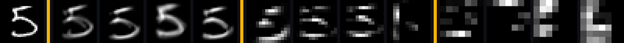

Nuestra CNN con un “5”: conv1 (28×28) · conv2 (14×14) · conv3 (7×7). Más abstracto y menos espacial en cada capa.

## Demo: MLP vs. CNN en vivo

Ambas redes en el navegador, mismo dibujo. Use **◀ 3 px / 3 px ▶** varias veces o apague el centrado: la CNN mantiene la predicción y sus mapas se desplazan con el dígito.

## Entrenar una CNN en Keras 3 (backend PyTorch)

import os os.environ["KERAS_BACKEND"] = "torch" # antes de importar keras import keras from keras import layers (x, y), (xt, yt) = keras.datasets.mnist.load_data() x, xt = x[..., None] / 255.0, xt[..., None] / 255.0 cnn = keras.Sequential([ keras.Input((28, 28, 1)), layers.Conv2D(16, 5, padding="same", activation="relu"), layers.MaxPooling2D(2), layers.Conv2D(32, 3, padding="same", activation="relu"), layers.MaxPooling2D(2), layers.Conv2D(32, 3, padding="same", activation="relu"), layers.GlobalAveragePooling2D(), layers.Dense(10, activation="softmax"), ]) cnn.summary() # 14 634 parámetros cnn.compile(optimizer="adam", loss="sparse_categorical_crossentropy", metrics=["accuracy"]) cnn.fit(x, y, batch_size=64, epochs=15, validation_data=(xt, yt))

|  | MLP | CNN |
| --- | --- | --- |
| Parámetros | 13 002 | 14 634 |
| Exactitud en prueba | 95.4 % | **98.1 %** |
| Desplazada 4 px | 34.2 % | **97.0 %** |
| Épocas | 15 | 15 |

- Mismo procedimiento que el MLP: datos etiquetados, entropía cruzada, retropropagación, **Adam**.
- Con los mismos ~14 mil parámetros, la CNN gana porque su estructura **encaja** con el problema (sesgo inductivo).

Script completo y reproducible: entrenar_mnist_demo.py (genera los modelos de esta presentación).

## Límites de las CNN y dónde están hoy

[figure not shown]

- **Datos:** requieren muchos ejemplos etiquetados (o transfer learning, sesión 7).
- **Robustez:** no son invariantes a rotación/escala; vulnerables a **ejemplos adversarios**; sesgo hacia la **textura** sobre la forma (Geirhos et al., 2019).
- **Interpretabilidad:** siguen siendo difíciles de explicar (Grad-CAM ayuda).

**ViT** (2020) compite con mucho dato; **ConvNeXt** (2022) mostró que una CNN modernizada iguala a los transformers. Detectores como YOLO siguen siendo mayormente convolucionales.

P1 · RPi: CNN ligeras (MobileNet)P4 · ARM: costo por capa convP2 · pocos datos → transfer learning

## Para recordar

[figure not shown]

- **Neurona** = suma ponderada + sesgo + activación. **Aprender** = bajar el costo con gradientes (retropropagación).
- **MLP en imágenes:** demasiados parámetros, no es invariante a la traslación y no respeta la vecindad (lo medimos).
- **Convolución:** filtros aprendidos, locales y compartidos; pooling y profundidad dan jerarquía e invariancia.

Igual que en Viola-Jones, la eficiencia es parte del diseño: la CNN ganó porque su estructura encaja con la de las imágenes.

[figure not shown]

Sesión 6 · Visión Artificial

# ¿Preguntas?

**Siguiente sesión:** redes clásicas (LeNet, AlexNet, VGG), ResNet, convolución 1×1, Inception y transfer learning.  
Dr. Víctor Alejandro González Huitrón · ITQ · TecNM

Sesión 6 · Redes neuronales → CNN

1 / 1